# DIABLO: Multi-Omics Integration with mixOmics on Breast TCGA Data

MixOmics

July 19, 2025

Let’s use `mixOmics` package for multi-omics data integration using the DIABLO (Data Integration Analysis for Biomarker discovery using Latent cOmponents) method on the breast TCGA dataset. We will go through data loading, pairwise PLS models, design matrix setup, model tuning, visualization, and performance evaluation. Checks(e.g., dimension prints, summaries) are included and printouts to verify each step.

## Load Libraries and Data

First, load the `mixOmics` library and set a seed for reproducibility. Then, load the breast TCGA data and prepare the input lists.

```r
library(mixOmics) # import the mixOmics library

set.seed(123) # for reproducibility, remove for normal use
```

```r
data(breast.TCGA) # load in the data

data = list(miRNA = breast.TCGA$data.train$mirna, # set a list of all the X dataframes
            mRNA = breast.TCGA$data.train$mrna,
            proteomics = breast.TCGA$data.train$protein)

# Check: Print dimensions of each dataset
lapply(data, dim) # check their dimensions
```

```
## $miRNA
## [1] 150 184
##
## $mRNA
## [1] 150 200
##
## $proteomics
## [1] 150 142
```

```r
Y = breast.TCGA$data.train$subtype # set the response variable as the Y dataframe

# Check: Summary of the response variable
summary(Y)
```

```
## Basal  Her2  LumA
##    45    30    75
```

**Note:** Verify the dimensions match expectations (e.g., same number of samples across omics). The summary shows the distribution of subtypes.

## Pairwise PLS Models

We build pairwise sparse PLS models to explore correlations between omics datasets. We plot circle correlation plots for visualization.

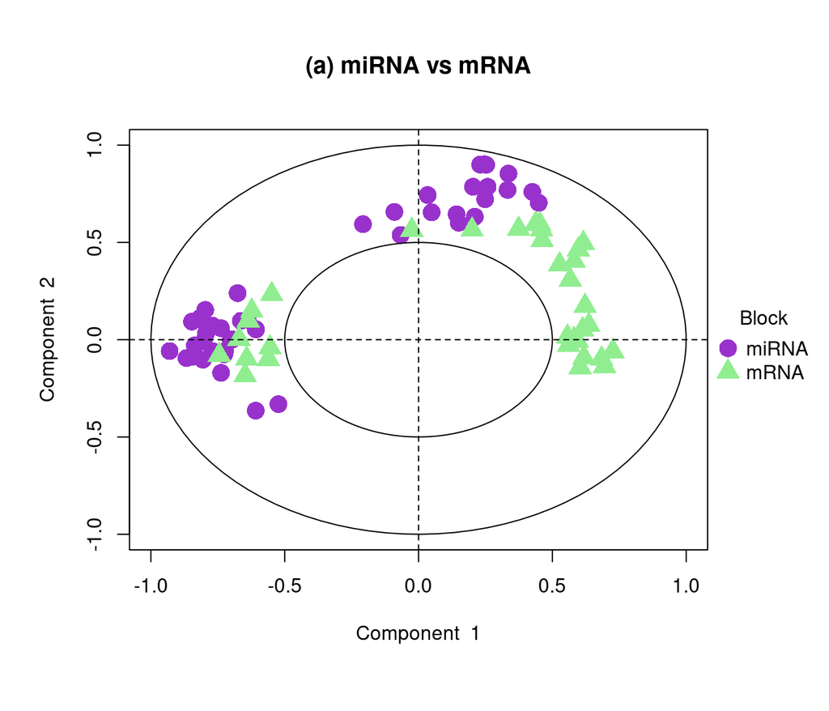

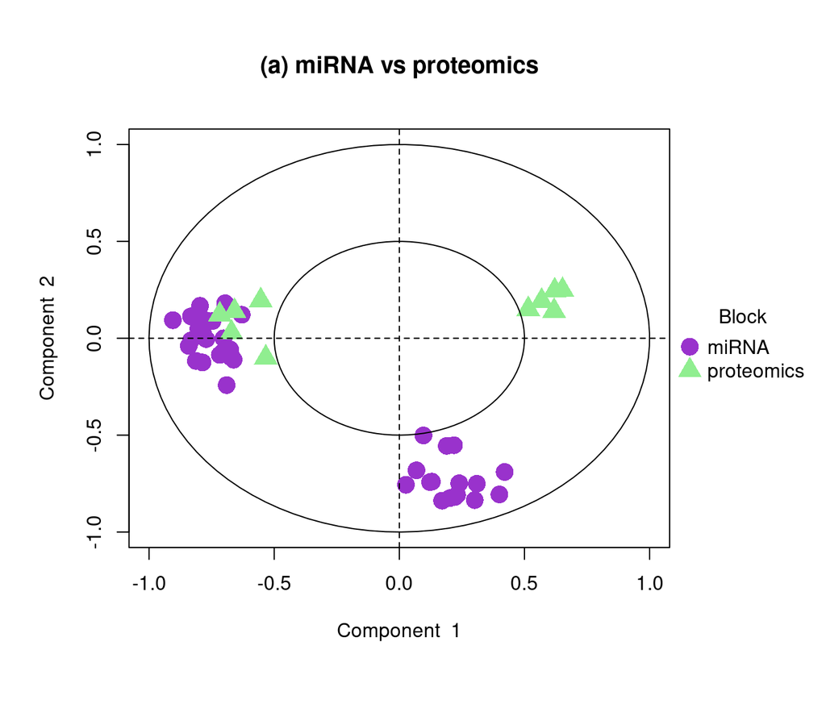

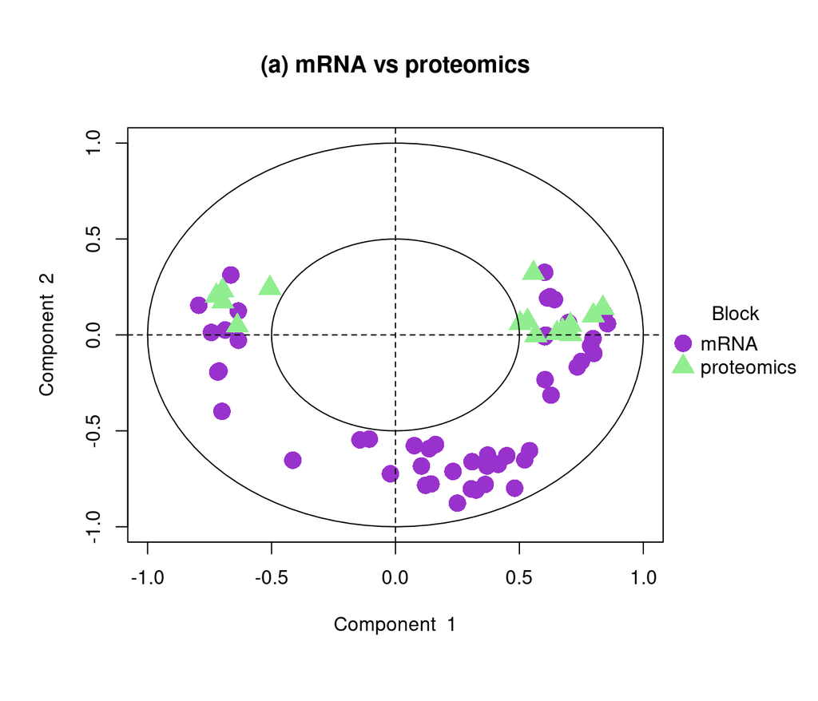

FIGURE 1: Circle Correlation Plots for pairwise PLS models on the breast TCGA data. Only displays the top 25 features for each dimension, subsetting by those with a correlation above 0.5.

```r
list.keepX = c(25, 25) # select arbitrary values of features to keep
list.keepY = c(25, 25)

pls1 <- spls(data[["miRNA"]], data[["mRNA"]], keepX = list.keepX, keepY = list.keepY) # generate three pairwise PLS models
pls2 <- spls(data[["miRNA"]], data[["proteomics"]], keepX = list.keepX, keepY = list.keepY)
pls3 <- spls(data[["mRNA"]], data[["proteomics"]], keepX = list.keepX, keepY = list.keepY)

plotVar(pls1, cutoff = 0.5, title = "(a) miRNA vs mRNA", legend = c("miRNA", "mRNA"), # plot features of first PLS
        var.names = FALSE, style = 'graphics',
        pch = c(16, 17), cex = c(2,2),
        col = c('darkorchid', 'lightgreen'))

plotVar(pls2, cutoff = 0.5, title = "(a) miRNA vs proteomics", legend = c("miRNA", "proteomics"), # plot features of second PLS
        var.names = FALSE, style = 'graphics',
        pch = c(16, 17), cex = c(2,2),
        col = c('darkorchid', 'lightgreen'))

plotVar(pls3, cutoff = 0.5, title = "(a) mRNA vs proteomics", legend = c("mRNA", "proteomics"), # plot features of third PLS
        var.names = FALSE, style = 'graphics',
        pch = c(16, 17), cex = c(2,2),
        col = c('darkorchid', 'lightgreen'))
```

**Note:** These plots show correlations between features. Check if the models converged properly by inspecting the outputs.

## Check Correlations

Calculate and print correlations between variates from pairwise models.

```r
cor(pls1$variates$X, pls1$variates$Y) # calculate correlation of miRNA and mRNA
```

```
##           comp1
## comp1 0.8841792
```

```r
cor(pls2$variates$X, pls2$variates$Y) # calculate correlation of miRNA and proteins
```

```
##           comp1
## comp1 0.8361993
```

```r
cor(pls3$variates$X, pls3$variates$Y) # calculate correlation of mRNA and proteins
```

```
##           comp1
## comp1 0.9360264
```

**Note:** Higher correlations indicate stronger associations between omics layers. Values above 0.5 are typically good.

## Design Matrix

Create a design matrix for the DIABLO model.

```r
design = matrix(0.1, ncol = length(data), nrow = length(data), # for square matrix filled with 0.1s
                dimnames = list(names(data), names(data)))
diag(design) = 0 # set diagonal to 0s

# Print the design matrix
design
```

```
##            miRNA mRNA proteomics
## miRNA        0.0  0.1        0.1
## mRNA         0.1  0.0        0.1
## proteomics   0.1  0.1        0.0
```

**Note:** The design matrix specifies connections between blocks. Off-diagonals are set to 0.1 for weak connections.

## Basic DIABLO Model

Fit a basic DIABLO model with 5 components.

```r
basic.diablo.model = block.splsda(X = data, Y = Y, ncomp = 5, design = design) # form basic DIABLO model
```

## Tune Number of Components

Use cross-validation to choose the optimal number of components.

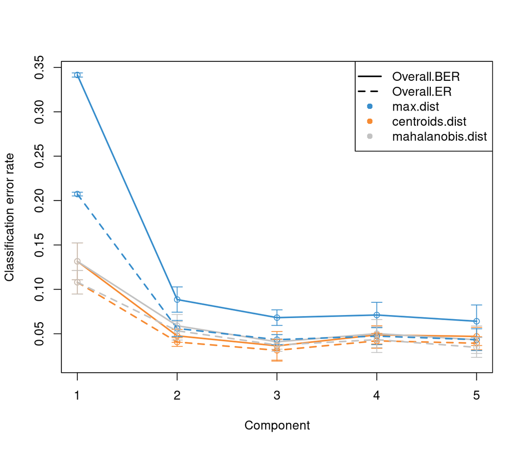

```r
perf.diablo = perf(basic.diablo.model, validation = 'Mfold', folds = 10, nrepeat = 10) # run component number tuning with repeated CV

plot(perf.diablo) # plot output of tuning
```

```r
ncomp = perf.diablo$choice.ncomp$WeightedVote["Overall.BER", "centroids.dist"] # set the optimal ncomp value

# Print the optimal choices
perf.diablo$choice.ncomp$WeightedVote # show the optimal choice for ncomp for each dist metric
```

```
##             max.dist centroids.dist mahalanobis.dist
## Overall.ER         3              2                3
## Overall.BER        3              2                3
```

**Note:** The plot helps select ncomp where error rates stabilize. Printout shows choices per metric.

## Tune Number of Features

Tune the number of features to keep per component. (Note: This chunk is set to eval=FALSE for time-saving; load precomputed results.)

```r
# Use the existing design matrix already created

test.keepX <- list(
  mRNA       = c(5:9, seq(10, 18, 2), seq(20, 30, 5)),
  miRNA      = c(5:9, seq(10, 18, 2), seq(20, 30, 5)),
  proteomics = c(5:9, seq(10, 18, 2), seq(20, 30, 5))
)

tune.TCGA <- tune.block.splsda(
  X          = data,
  Y          = Y,
  ncomp      = ncomp,
  test.keepX = test.keepX,
  design     = design,
  validation = "Mfold",
  folds      = 10,
  nrepeat    = 1,
  dist       = "centroids.dist"
)
```

```r
list.keepX = tune.TCGA$choice.keepX # set the optimal values of features to retain

# Print the optimal keepX
list.keepX
```

```
## $mRNA
## [1] 15
##
## $miRNA
## [1] 15
##
## $proteomics
## [1] 10
```

Tuning selects sparse features. Check the list for reasonableness (e.g., not too few or many).

## Final DIABLO Model

Fit the final optimized DIABLO model.

```r
final.diablo.model = block.splsda(X = data, Y = Y, ncomp = ncomp, # set the optimised DIABLO model
                          keepX = list.keepX, design = design)
```

```r
# Check: Print the design matrix of the final model
final.diablo.model$design # design matrix for the final model
```

```
##            miRNA mRNA proteomics Y
## miRNA        0.0  0.1        0.1 1
## mRNA         0.1  0.0        0.1 1
## proteomics   0.1  0.1        0.0 1
## Y            1.0  1.0        1.0 0
```

```r
# Check: Selected variables for mRNA on component 1
selectVar(final.diablo.model, block = 'mRNA', comp = 1)$mRNA$name # the features selected to form the first component
```

```
##  [1] "ZNF552"  "KDM4B"   "CCNA2"   "LRIG1"   "PREX1"   "FUT8"    "C4orf34"
##  [8] "TTC39A"  "ASPM"    "SLC43A3" "MEX3A"   "SEMA3C"  "E2F1"    "STC2"
## [15] "FMNL2"
```

**Note:** Verify the model design matches input. Selected variables should be printed for inspection.

## Visualizations

### Diagnostic Plot

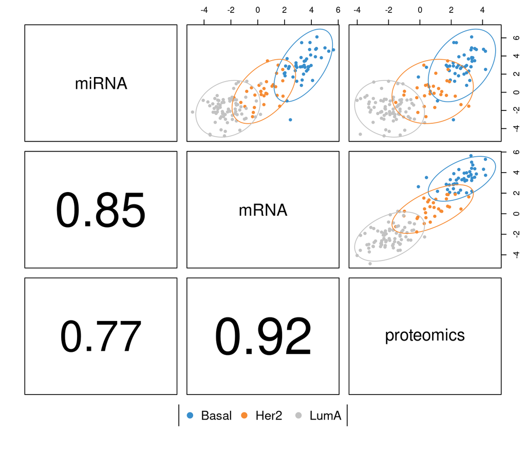

FIGURE 3: Diagnostic plot from multiblock sPLS-DA applied on the `breast.TCGA` study. Samples are represented based on the specified component (here `ncomp = 1`) for each data set (mRNA, miRNA and protein). Samples are coloured by breast cancer subtype and 95% confidence ellipse plots are represented.

```r
plotDiablo(final.diablo.model, ncomp = 1)
```

### Sample Plot

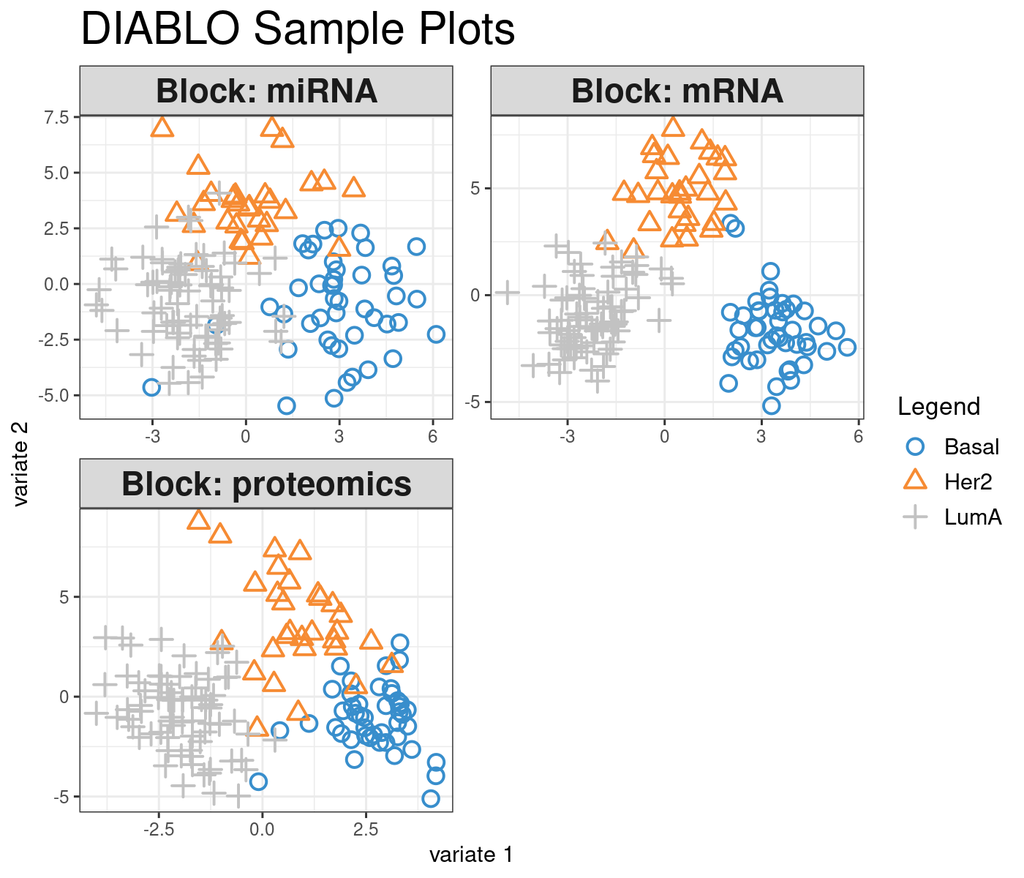

FIGURE 4: Sample plot from multiblock sPLS-DA performed on the `breast.TCGA` study. The samples are plotted according to their scores on the first 2 components for each data set. Samples are coloured by cancer subtype

```r
plotIndiv(final.diablo.model, ind.names = FALSE, legend = TRUE, title = 'DIABLO Sample Plots')
```

### Arrow Plot

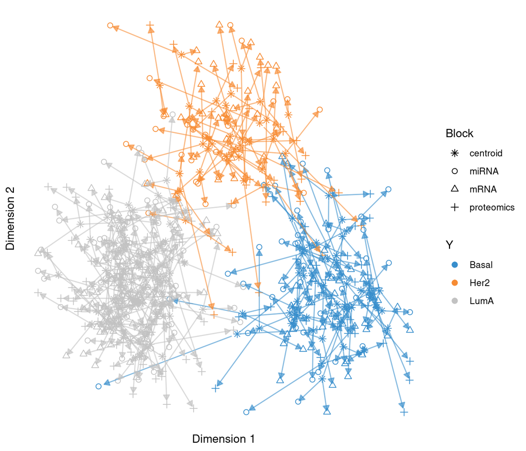

FIGURE 5: Arrow plot from multiblock sPLS-DA performed on the `breast.TCGA` study. The samples are projected into the space spanned by the first two components for each data set then overlaid across data sets.

```r
plotArrow(final.diablo.model, ind.names = FALSE, legend = TRUE, title = 'DIABLO')
```

### Correlation Circle Plot

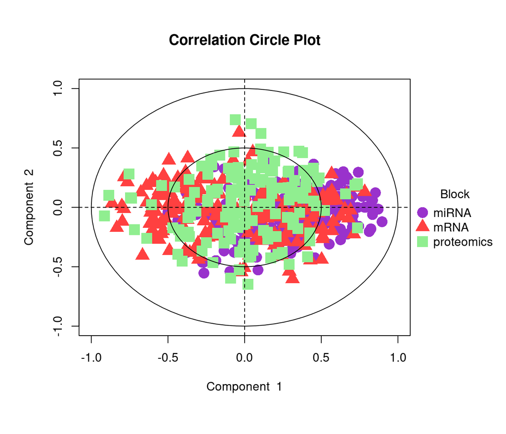

FIGURE 6: Correlation circle plot from multiblock sPLS-DA performed on the `breast.TCGA` study. Variable types are indicated with different symbols and colours, and are overlaid on the same plot.

```r
plotVar(final.diablo.model, var.names = FALSE, style = 'graphics', legend = TRUE,
        pch = c(16, 17, 15), cex = c(2,2,2), col = c('darkorchid', 'brown1', 'lightgreen'))
```

### Circos Plot

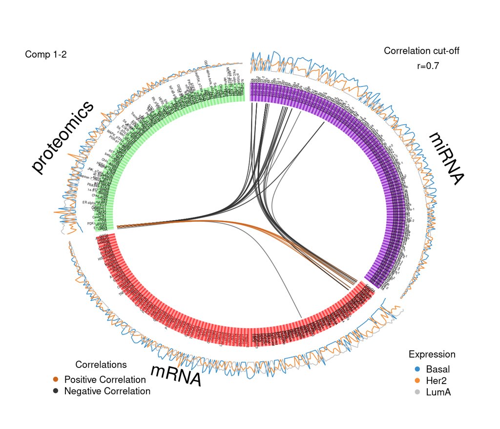

FIGURE 7: Circos plot from multiblock sPLS-DA performed on the `breast.TCGA` study. The plot represents the correlations greater than 0.7 between variables of different types, represented on the side quadrants

```r
circosPlot(final.diablo.model, cutoff = 0.7, line = TRUE,
           color.blocks= c('darkorchid', 'brown1', 'lightgreen'),
           color.cor = c("chocolate3","grey20"), size.labels = 1.5)
```

### Relevance Network

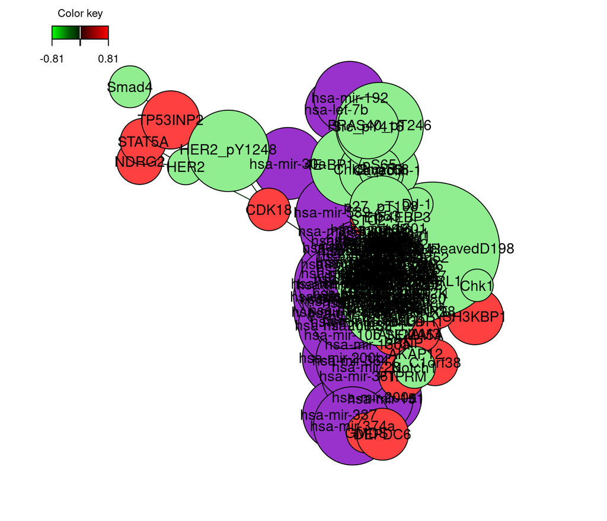

FIGURE 8: Relevance network for the variables selected by multiblock sPLS-DA performed on the `breast.TCGA` study on component 1. Each node represents a selected with colours indicating their type. The colour of the edges represent positive or negative correlations

```r
network(final.diablo.model, blocks = c(1,2,3),
        color.node = c('darkorchid', 'brown1', 'lightgreen'), cutoff = 0.4)
```

Optionally, export the network (eval=FALSE).

```r
library(igraph)
my.network = network(final.diablo.model, blocks = c(1,2,3),
        color.node = c('darkorchid', 'brown1', 'lightgreen'), cutoff = 0.4)
write.graph(my.network$gR, file = "myNetwork.gml", format = "gml")
```

### Loading Plot

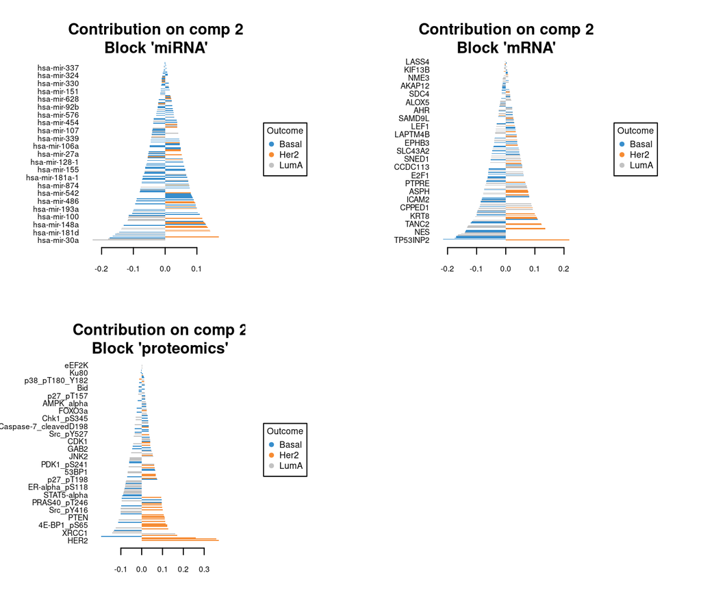

```r
plotLoadings(final.diablo.model, comp = 2, contrib = 'max', method = 'median')
```

### Clustered Image Map

```r
cimDiablo(final.diablo.model)
```

```
##
## trimming values to [-3, 3] range for cim visualisation. See 'trim' arg in ?cimDiablo
```

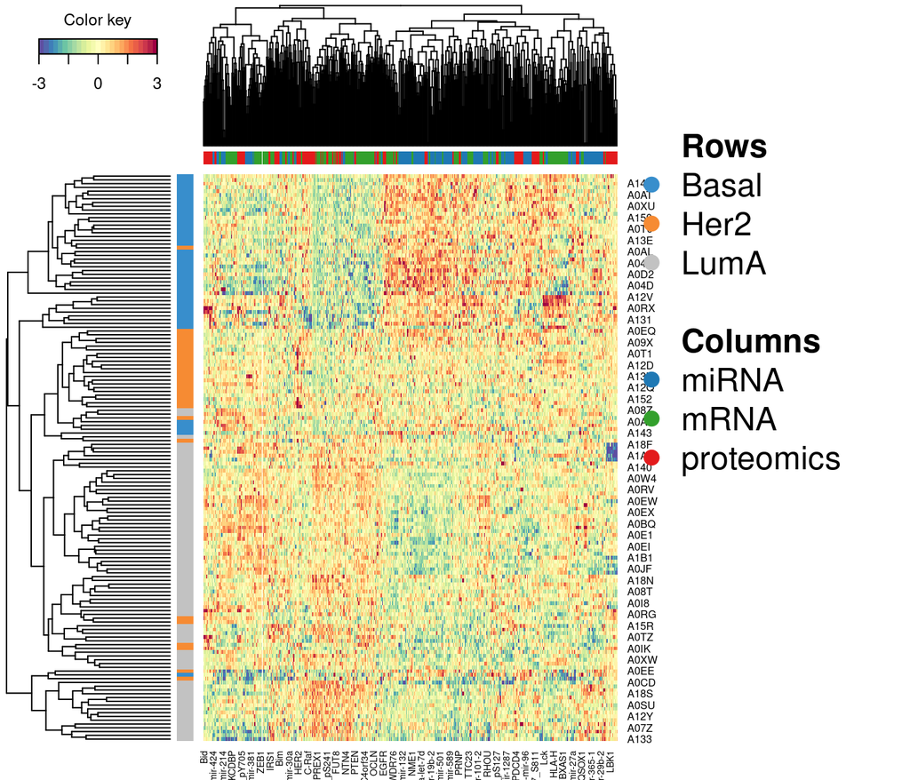

FIGURE 10: Clustered Image Map for the variables selected by multiblock sPLS-DA performed on the `breast.TCGA` study on component 1. By default, Euclidean distance and Complete linkage methods are used. The CIM represents samples in rows (indicated by their breast cancer subtype on the left hand side of the plot) and selected features in columns (indicated by their data type at the top of the plot).

**Note:** These visualizations help interpret the model. Check for separation by subtypes and strong correlations.

## Performance Evaluation

Perform repeated cross-validation on the final model.

```r
perf.diablo = perf(final.diablo.model, validation = 'Mfold', M = 10, nrepeat = 10,
                   dist = 'centroids.dist') # run repeated CV performance evaluation

# Print error rates
perf.diablo$MajorityVote.error.rate
```

```
## $centroids.dist
##                  comp1      comp2
## Basal       0.02888889 0.04666667
## Her2        0.20666667 0.08666667
## LumA        0.05466667 0.05066667
## Overall.ER  0.07733333 0.05666667
## Overall.BER 0.09674074 0.06133333
```

```r
perf.diablo$WeightedVote.error.rate
```

```
## $centroids.dist
##                  comp1      comp2
## Basal       0.01333333 0.03777778
## Her2        0.14000000 0.08333333
## LumA        0.05466667 0.04533333
## Overall.ER  0.05933333 0.05066667
## Overall.BER 0.06933333 0.05548148
```

### ROC and AUC

```r
auc.splsda = auroc(final.diablo.model, roc.block = "miRNA", roc.comp = 2, print = FALSE)
```

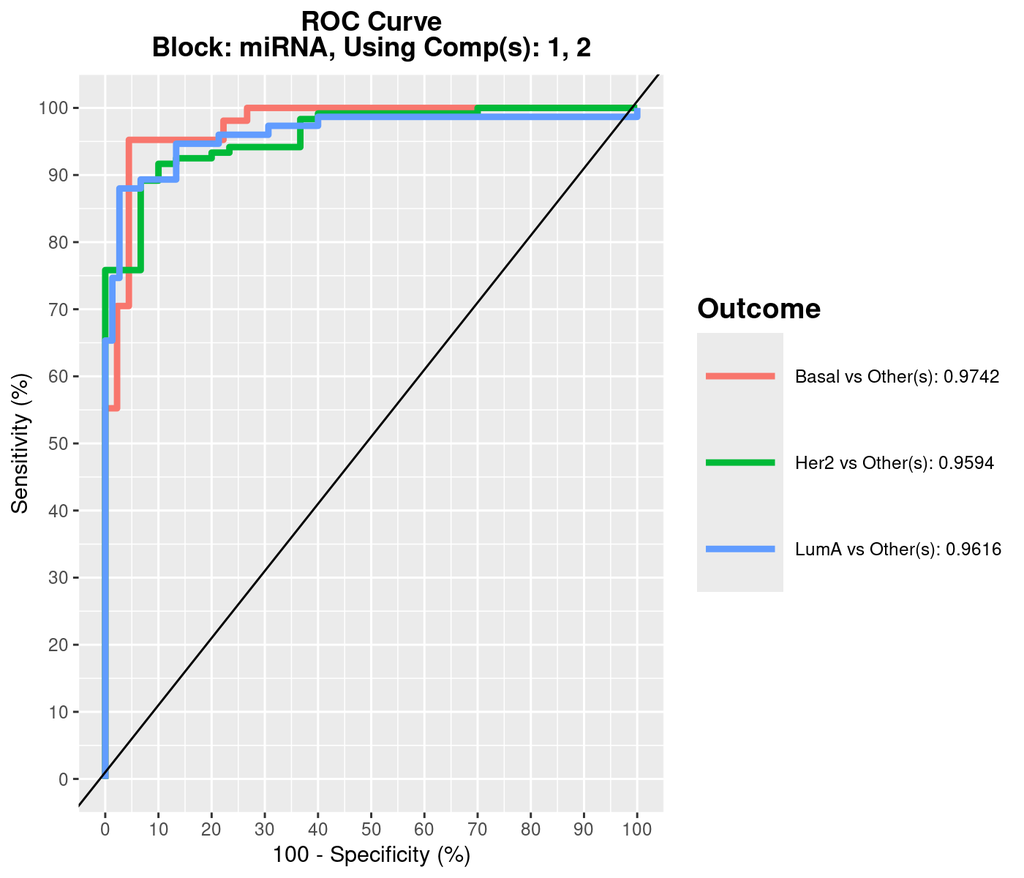

FIGURE 11: ROC and AUC based on multiblock sPLS-DA performed on the `breast.TCGA` study for the miRNA data set after 2 components. The function calculates the ROC curve and AUC for one class vs. the others.

**Note:** Low error rates and high AUC indicate good performance. Inspect for overfitting.

## Prediction on Test Data

Prepare test data and predict.

```r
data.test.TCGA = list(mRNA = breast.TCGA$data.test$mrna,
                      miRNA = breast.TCGA$data.test$mirna)

predict.diablo = predict(final.diablo.model, newdata = data.test.TCGA)
```

```r
confusion.mat = get.confusion_matrix(truth = breast.TCGA$data.test$subtype,
                     predicted = predict.diablo$WeightedVote$centroids.dist[,2])

# Print confusion matrix
confusion.mat
```

```
##       predicted.as.Basal predicted.as.Her2 predicted.as.LumA
## Basal                 19                 2                 0
## Her2                   0                14                 0
## LumA                   0                 1                34
```

```r
# Print Balanced Error Rate
get.BER(confusion.mat)
```

```
## [1] 0.04126984
```

**Note:** The confusion matrix and BER assess predictive accuracy on unseen data.

## Session Information

- render the Rmd with `rmarkdown::render("case_study/DIABLO_TCGA_Case_Study.Rmd")`